# Functional Data Analysis

양성준(seong.j.yang@gmail.com)

# 1. Introduction

Some references

- Ramsay & Silverman, 2005, “Functional Data Analysis”
- Ramsay & Silverman, 2002, “Applied Functional Data Analysis”
- Ramsay, Hooker & Graves, 2009, “Functional Data Analysis in R and Matlab”

R packages

- `fda`
- `fda.ucs`
- `refund`
- $\cdots$

See https://cran.r-project.org/web/views/FunctionalData.html

#### Example : Canadian weather data

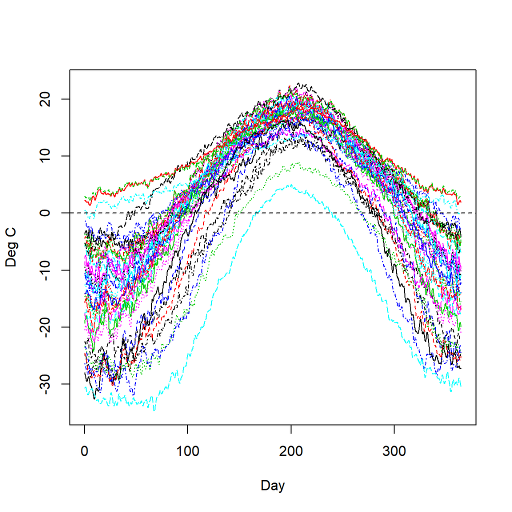

```
## [1] "done"
```

```r
# making a functional object
Tem <- Data2fd(day.5, CanadianWeather$dailyAv[,,"Temperature.C"],
                        fdnames=list("Day", "Station", "Deg C"))
plot(Tem)
```

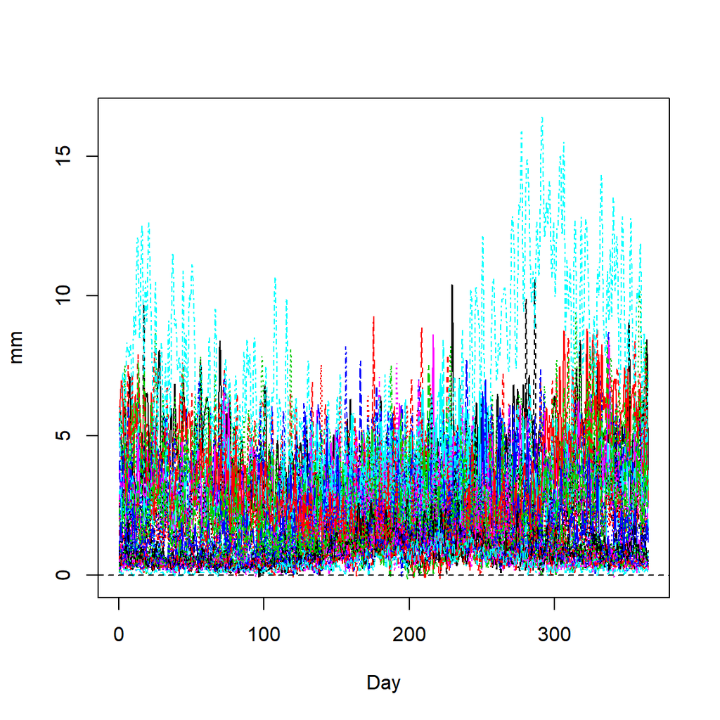

```
## [1] "done"
```

```r
Pre <- Data2fd(day.5, CanadianWeather$dailyAv[,,"Precipitation.mm"],
                          fdnames=list("Day", "Station", "mm"))
plot(Pre)
```

#### Example : fMRI data

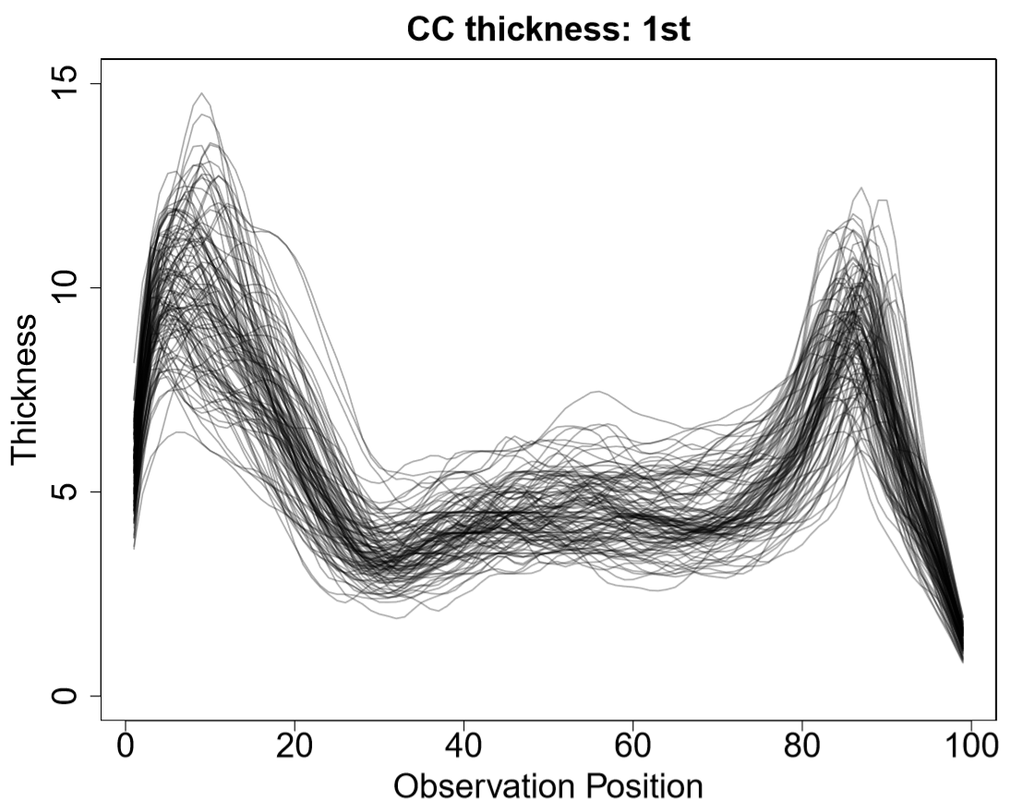

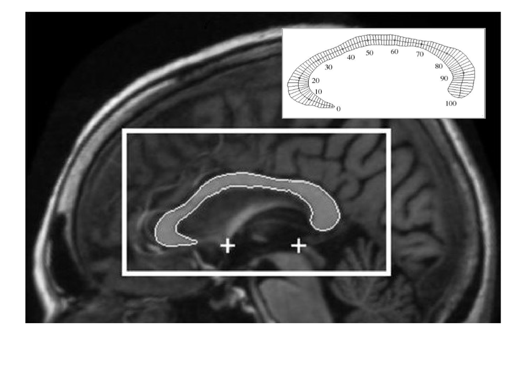

#### Example : growth data

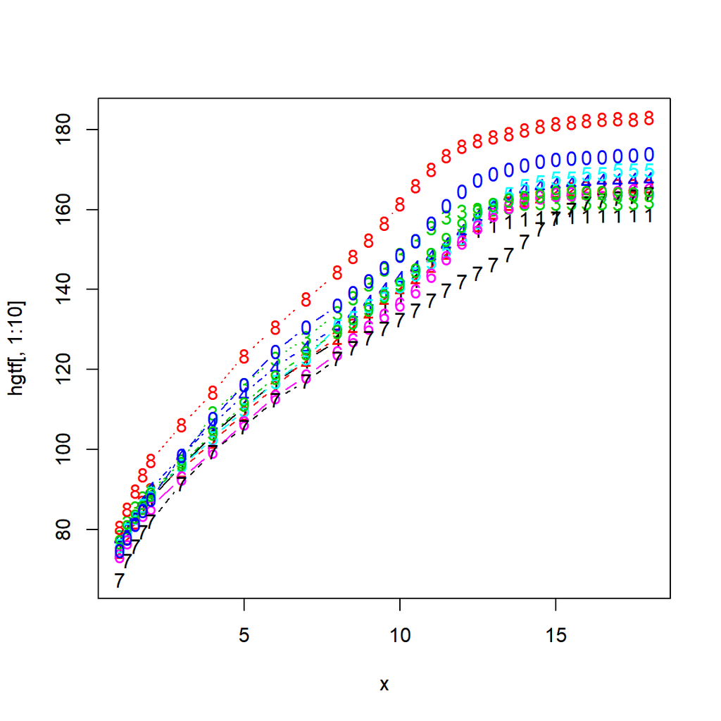

```r
with(growth, matplot(age, hgtf[, 1:10], type="b")) # matrix plot
```

“Functional data is multivariate data with an ordering on the dimensions” (Muller, 2006)

$$y_{ij} = x_i(t_{ij}) + (\epsilon_{ij})$$

- Conceptually, we regard functional data as being smooth.
- In practice, functional data are observed at discrete (finite) points.
- Very Often, functional data are high-dimensional.
- Time points where observations are taken may not be equally-spaced.

#### Interests?

1. Exploration of data characteristics
- mean, covariance
- principal components
2. Relationships of functional data
- functional regression
3. Others
- classification
- clustering

#### Difficulties?

1. Noise
2. Infinite-dimensional
3. Interpretation
4. Theory
5. $n<p$ : regularization

#### Representing functional data as smooth functions

Why?

만약, 데이터가 오차 없이 관측되었고, 같은 집합 위에서 충분히 밀도 있게 얻어졌다면, 이 과정은 생략할 수 있다.

There are two popuar approaches

1. Basis function methods
2. Smmothing by local weighting

위 두 방법은 비모수함수추정의 대표적인 두 접근방법이다. 이론적인 관점에서는 두 방법 모두 활발히 연구되고 있으나, practical하게는 basis에 근거한 방법이 좀 더 널리 쓰이는 것으로 보인다.

#### Roughness penalty approach

Assume that there is a single curve

$$y_i = x(t_i) + \epsilon_i$$

다음과 같은 basis expansion을 고려

$$x(t) \approx \sum_{j=1}^K c_j \phi_j(t)$$

다음을 최소화하는 $c_j$들을 선택

$$\sum_{i=1}^n (y_i - x(t_i))^2 = \sum_{i=1}^n \left(y_i - \sum_{j=1}^K c_j \phi_j(t_i)\right)^2$$

만약, basis function의 개수를 충분히 많이 선택하면 위 값을 항상 0으로 만드는 게 가능! $\rightarrow$ $x(\cdot)$의 smoothness를 적당히 보장하는 penalty 부여.

Minimize

$$\sum_{i=1}^n (y_i - x(t_i))^2 + \lambda \int [x''(t)]^2 dt$$

#### Example : Smoothing by Fourier basis

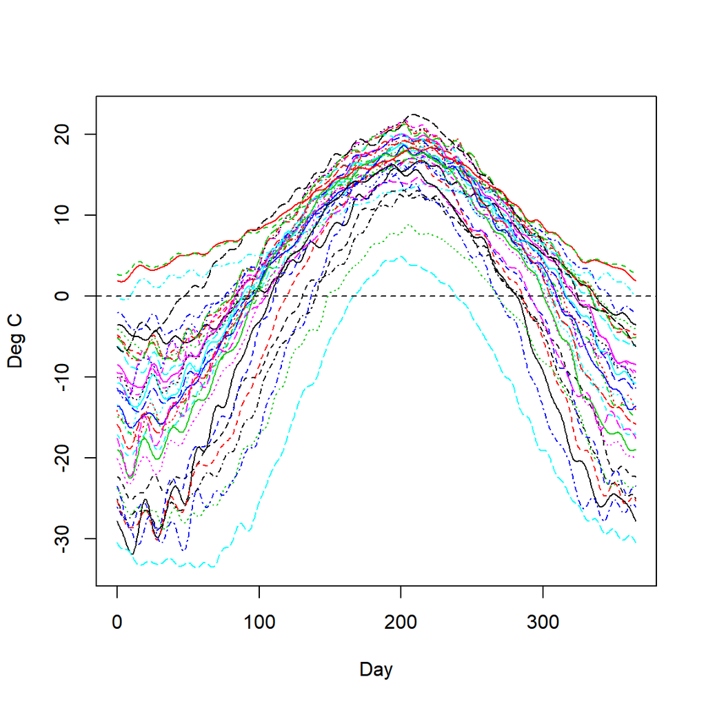

```
## [1] "done"
```

```r
daybasis65 <- create.fourier.basis(c(0, 365), nbasis=65, period=365)    # creating a basis object
#### making a smoothed functional object based on created basis ####
daytempfd <- smooth.basis(day.5, CanadianWeather$dailyAv[,,"Temperature.C"],
                          daybasis65, fdnames=list("Day", "Station", "Deg C"))$fd
plot(daytempfd)
```

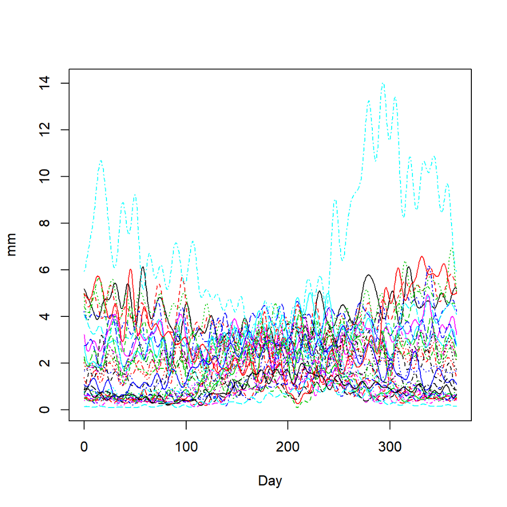

```
## [1] "done"
```

```r
dayprefd <- smooth.basis(day.5, CanadianWeather$dailyAv[,,"Precipitation.mm"],
                          daybasis65, fdnames=list("Day", "Station", "mm"))$fd
plot(dayprefd)
```

#### Example : Smoothing by B-spline basis

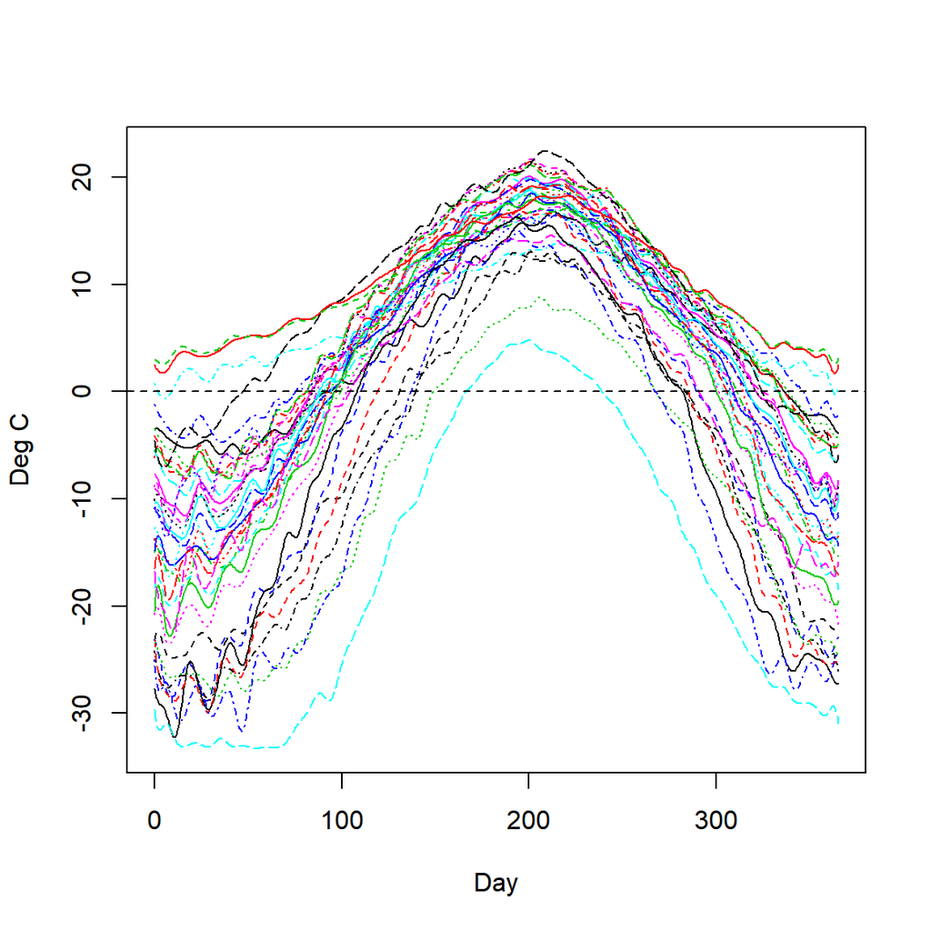

```
## [1] "done"
```

```r
daybasis65 <- create.bspline.basis(c(0, 365), nbasis=65, norder=4)
daytempfd <- smooth.basis(day.5, CanadianWeather$dailyAv[,,"Temperature.C"],
                          daybasis65, fdnames=list("Day", "Station", "Deg C"))$fd
plot(daytempfd)
```

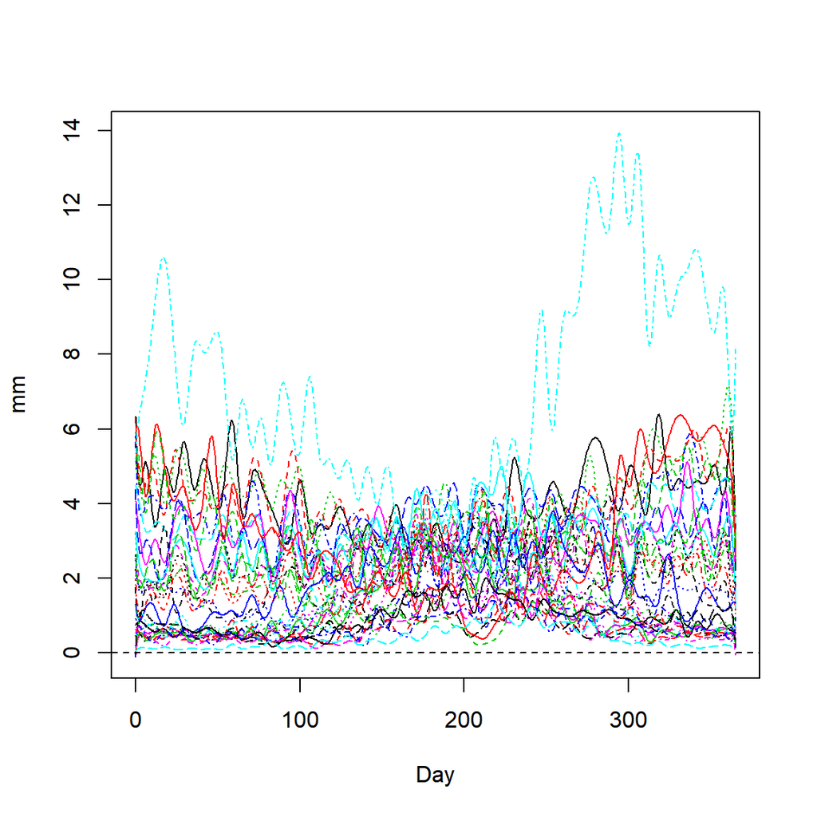

```
## [1] "done"
```

```r
dayprefd <- smooth.basis(day.5, CanadianWeather$dailyAv[,,"Precipitation.mm"],
                          daybasis65, fdnames=list("Day", "Station", "mm"))$fd
plot(dayprefd)
```

#### Example : Smoothing by B-spline basis (control $\lambda$)

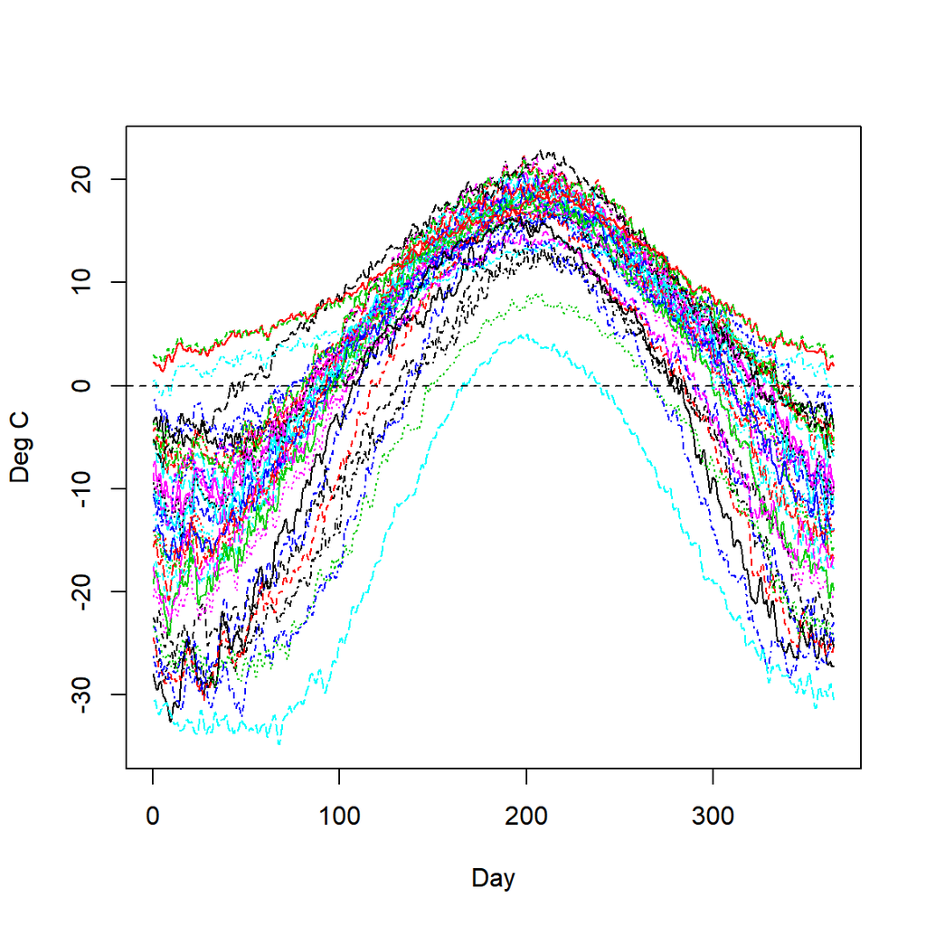

```
## [1] "done"
```

```r
Tem <- Data2fd(day.5, CanadianWeather$dailyAv[,,"Temperature.C"],
                          fdnames=list("Day", "Station", "Deg C")) # functional object
yfdPar <- fdPar(Tem, 2, 1e-3)   # define a functional parameter object
#### making a smoothed functional object using a user-specified penalty ####
yfd1 <- smooth.fd(Tem, yfdPar)
plot(yfd1)
```

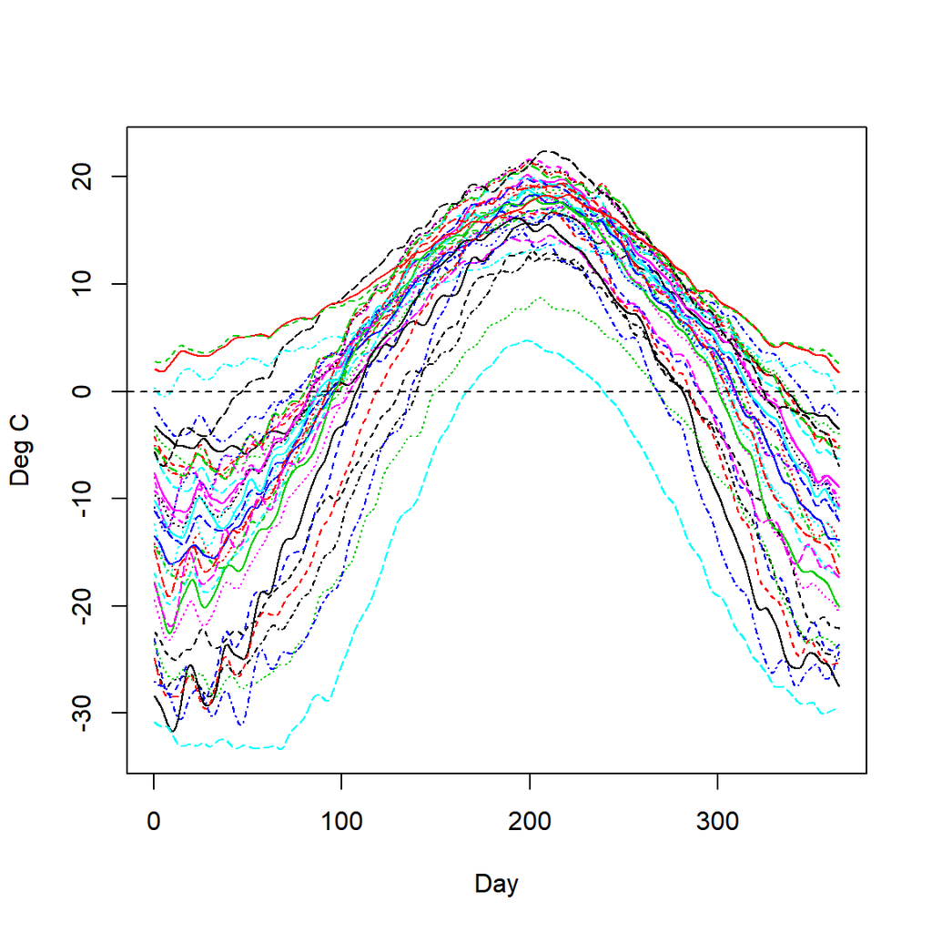

```
## [1] "done"
```

```r
yfdPar2 <- fdPar(Tem, 2, 10)

yfd2 <- smooth.fd(Tem, yfdPar2)
plot(yfd2)
```

#### Mean function estimation

$$\bar x(t) = n^{-1} \sum_{i=1}^n x_i(t)$$

```r
m_tem = mean.fd(Tem)     # mean function evaluation
plot(Tem,lwd=0.1,col=1,lty="dashed")
```

```
## [1] "done"
```

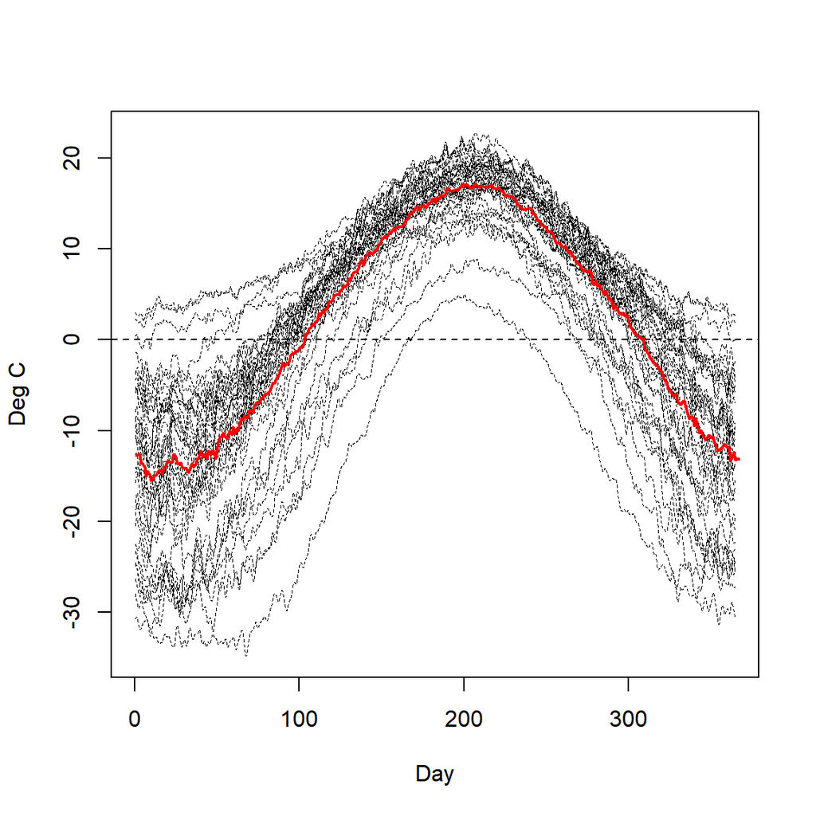

```r
lines(m_tem$coefs,lwd=2,col=2)
```

Smoothing may be needed.

#### Covariance function estimation

$$\sigma(s,t) = n^{-1} \sum_{i=1}^n ( x_i(s) - \bar x(s)) ( x_i(t) - \bar x(t))$$

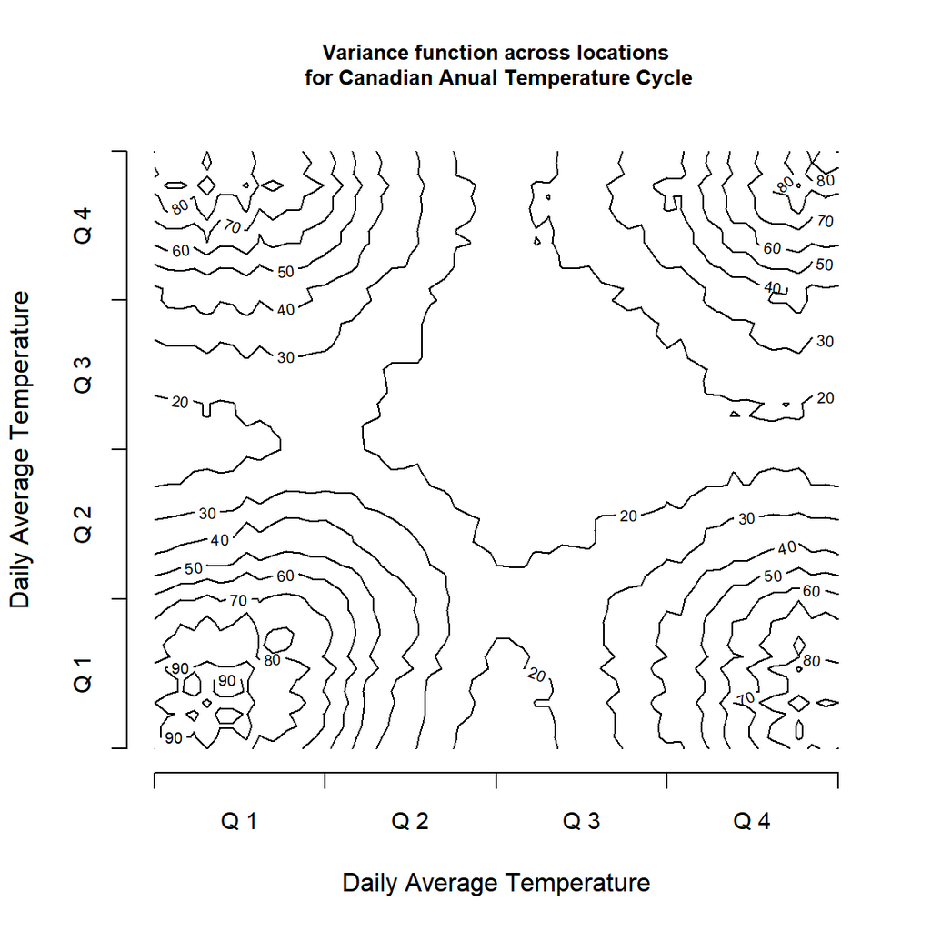

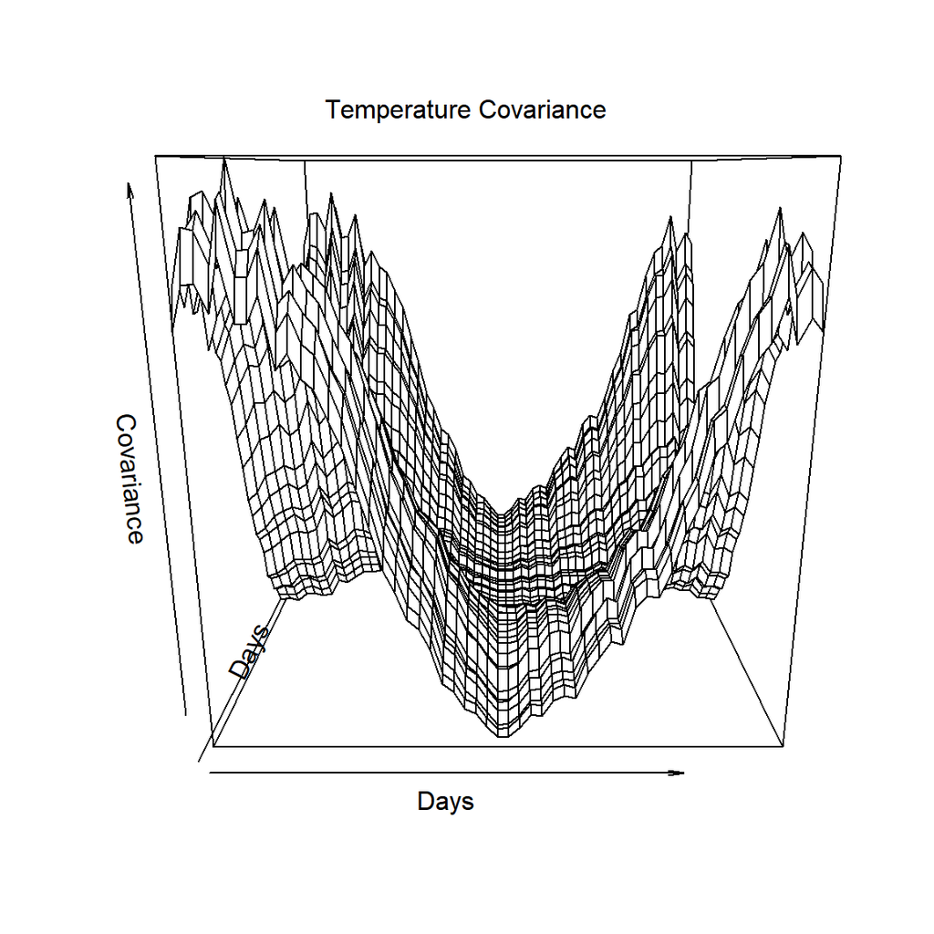

Smoothing may be needed.

#### Correlation function estimation

$$\rho(s,t) = \frac{\sigma(s,t)}{\sqrt{\sigma(s,s)}\sqrt{\sigma(t,t)}}$$

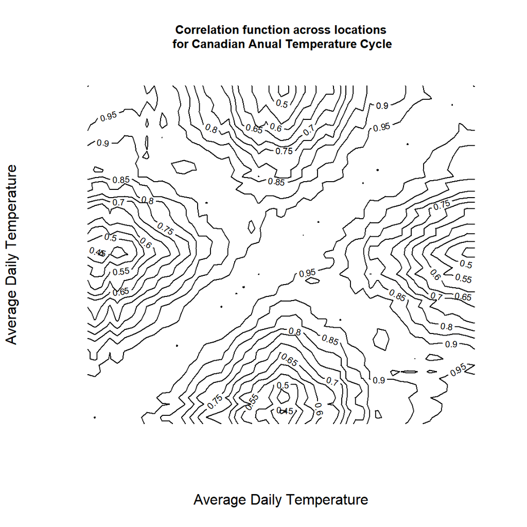

# 2. Functional Principal Component Analysis

Most sets of data display a small number of dominant or substantial modes of variation.

Recall that the notion of PCA in multivariate analysis

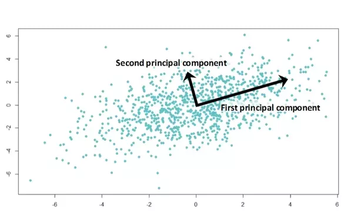

#### Karhunen-Loève decomposition

$$\sigma(s,t) = \sum_{j=1}^\infty d_j \xi_j(s)\xi_j(t)$$

for $\int \xi_i(t)\xi_j(t)dt = I(i=j)$.

$d_j$ : eigenvalues & $\xi_i(\cdot)$ : eigenfunctions

Then,

$$x_i(t) = \bar x (t) + \sum_{j=1}^\infty f_{ij}\xi_j(t)$$

where $f_{ij}$ are principal component scores defined as

$$f_{ij} = \int \xi_j(t) [x_i(t)-\bar x(t)]dt$$

Note that

- $d_i = Var(f_{ij})$
- $d_i/\sum_i d_i$ is proportion of variance explained

#### Example : Weather data

$$\bar x(t) \pm c_j\xi_j(t) ~{\rm plots}$$

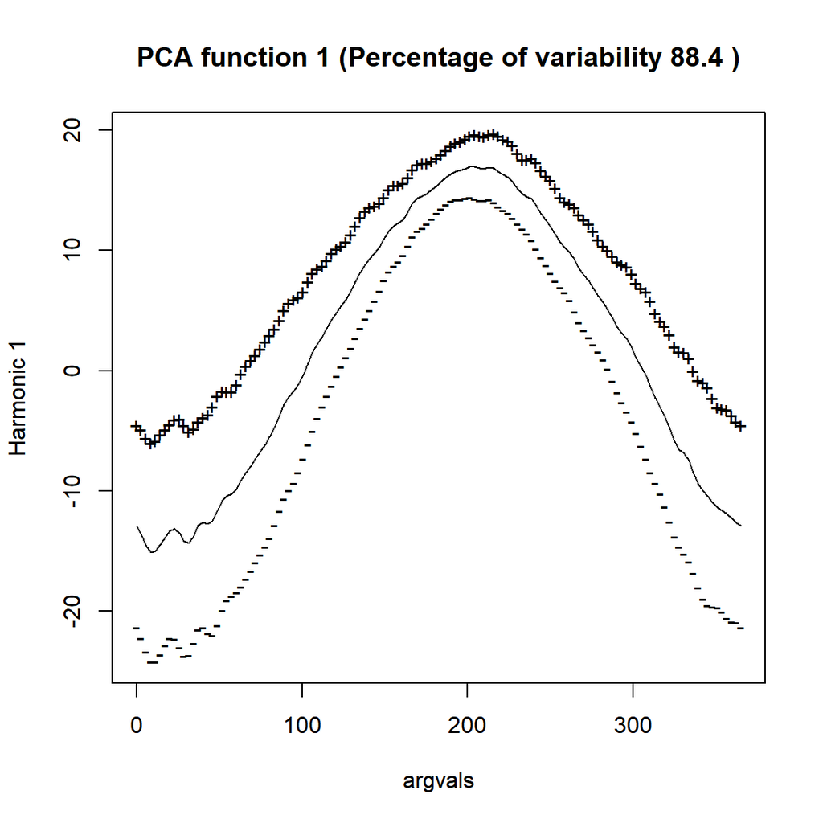

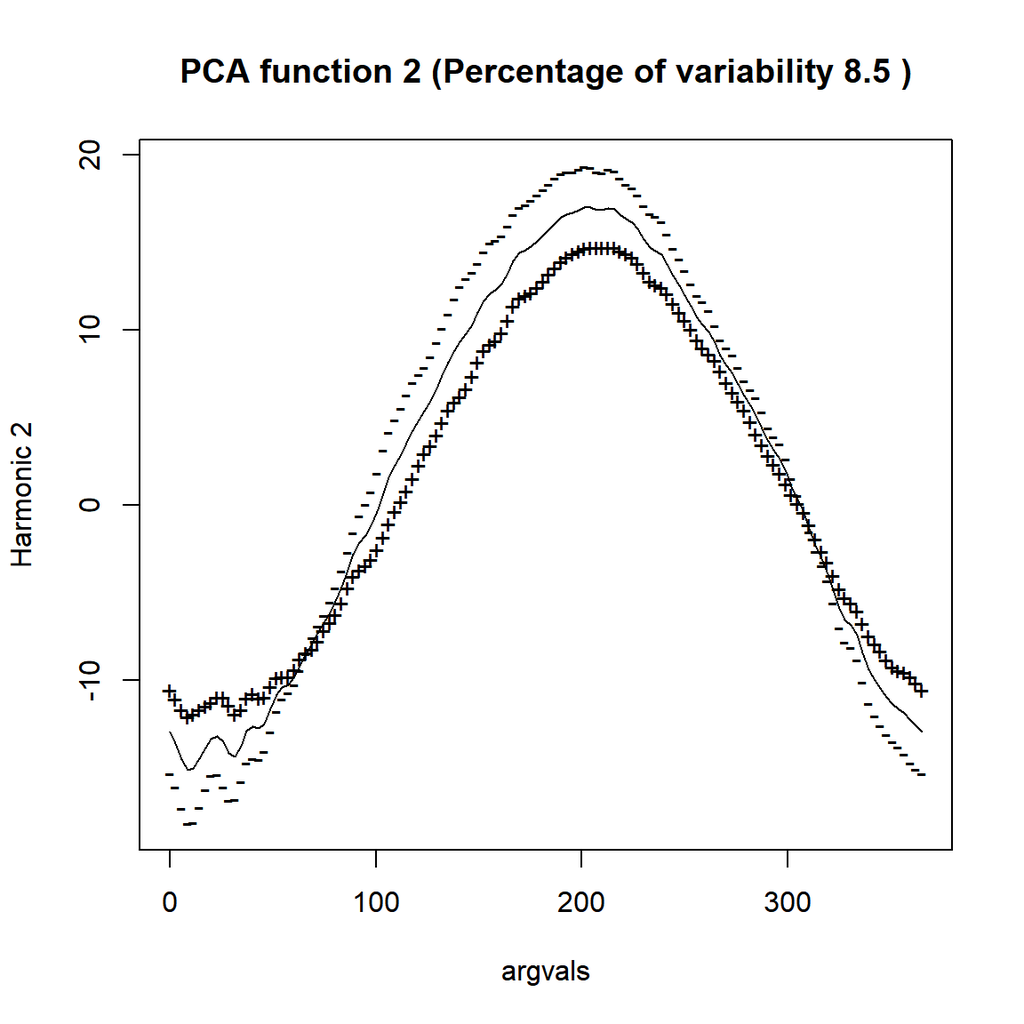

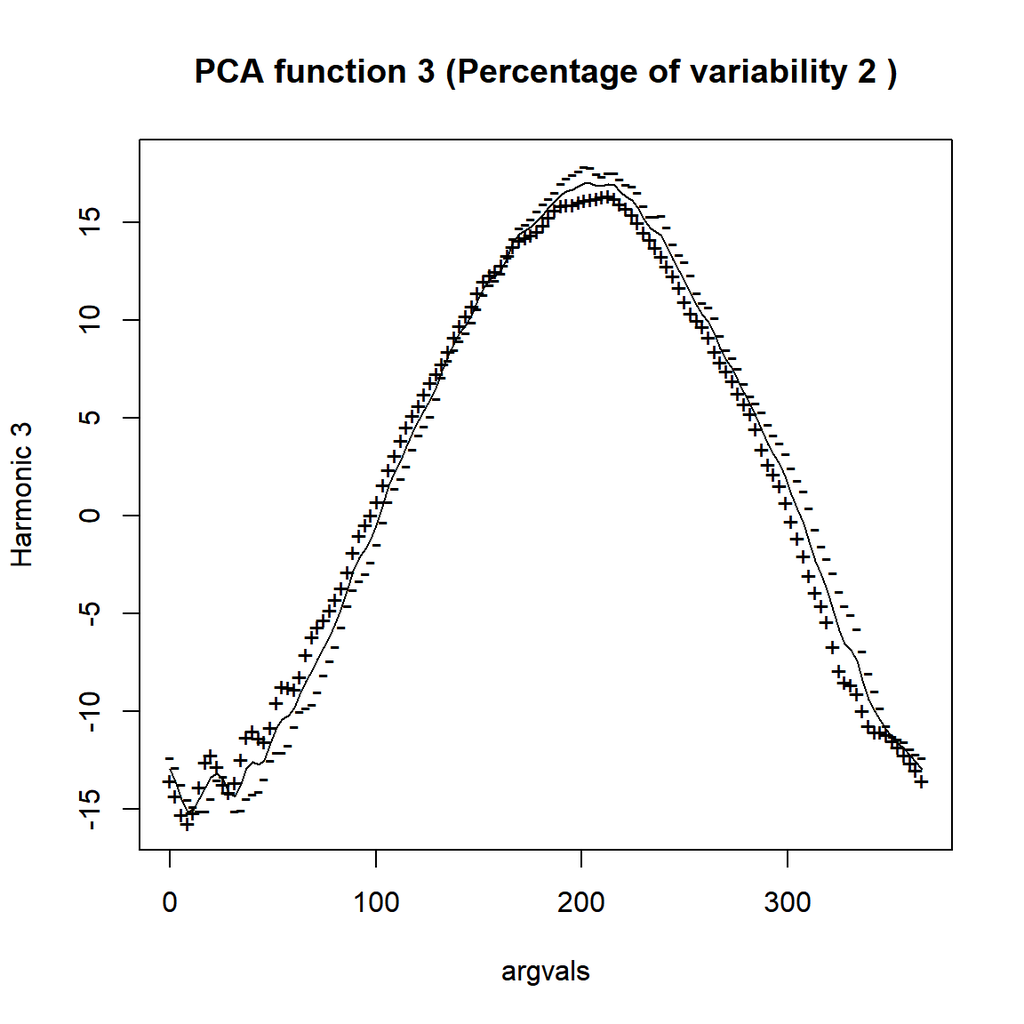

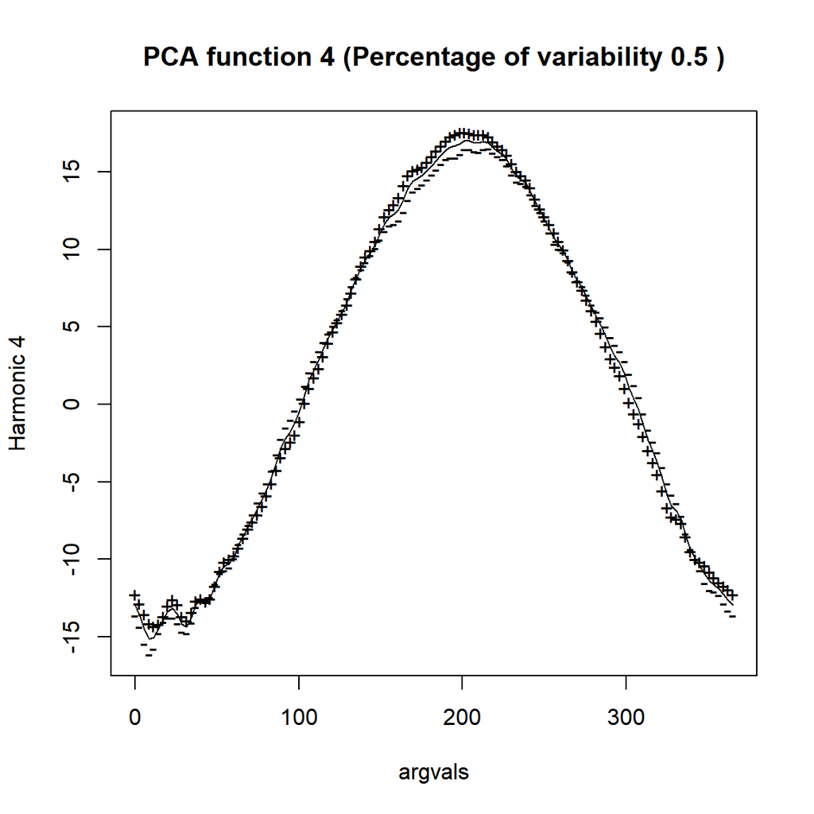

```r
daytemppcaobj <- pca.fd(daytempfd, nharm=4)   # producing a pca functional object
plot.pca.fd(daytemppcaobj)                    # plotting PC functions
```

PC functions

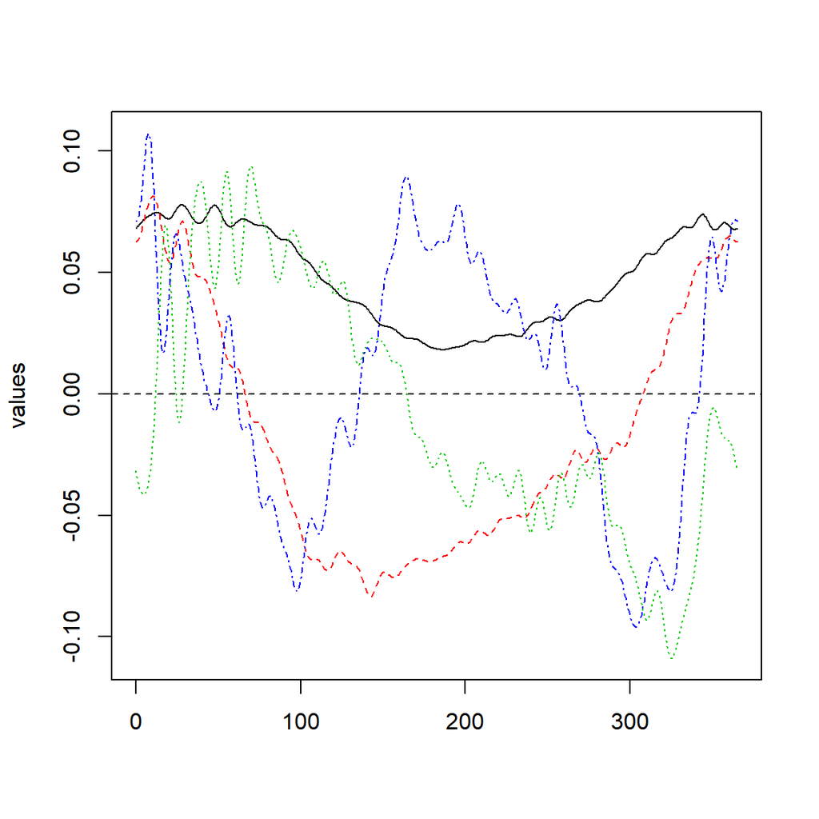

```
## [1] "done"
```

```r
plot(daytemppcaobj$harmonics)
```

Smoothing sometimes gives a better result.

Scatterplot for the first 2 PCs

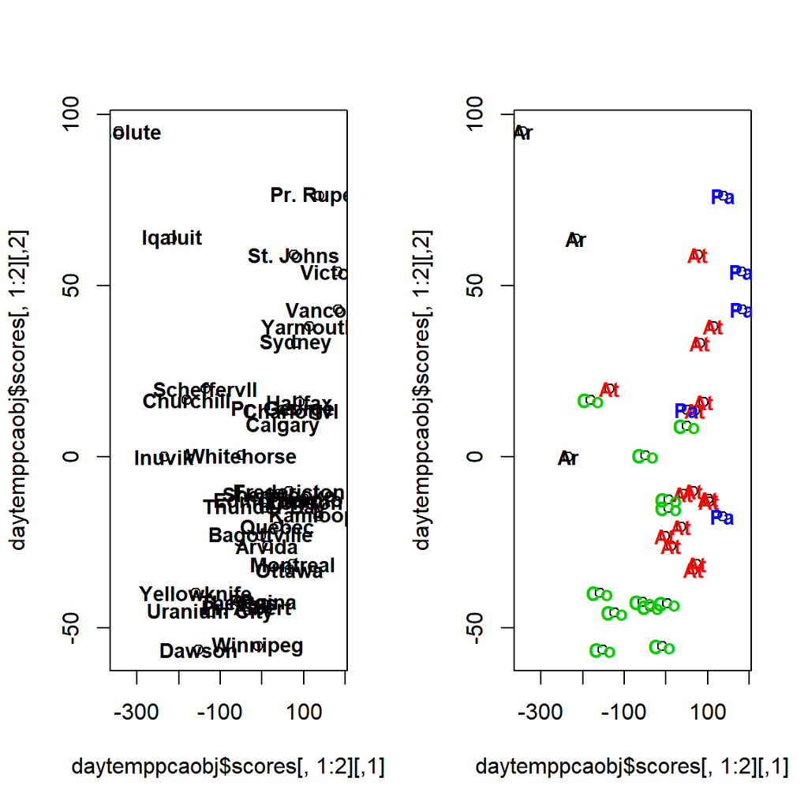

```r
par(mfrow=c(1,2))
plot(daytemppcaobj$scores[,1:2])   # extracting the first 2 PC scores
text(daytemppcaobj$scores[,1:2], labels=colnames(Tem$coefs), cex=0.9, font=2)
plot(daytemppcaobj$scores[,1:2])
text(daytemppcaobj$scores[,1:2], labels=substr(CanadianWeather$region,start=1,stop=2), cex=0.9, font=2,col=as.numeric(factor(CanadianWeather$region)))
```

# 3. Funtional linear regression

There are 3 modes

1. Functional covariate, scalar response : temperature vs rainfall, image vs clinical outcome
2. Functional covariate, functional response : temparature vs precipitation
3. scalar covariate, functional response : climate zone vs temparature, diagnosis vs image

#### Functional linear model for scalar responses

$$y_i = \alpha + \int x_i(t)\beta(t) dt + \epsilon_i$$

Note that this is a natural extension of the ordinary multiple linear regression model.

$$y_i = \alpha+ \sum_{j=1}^p x_{ij} \beta_j + \epsilon_i$$

Estimation?

Since the regression parameter $\beta(\cdot)$ is infite-dimensional, regularization is necessary.

$$PEN(\beta) = \sum_{i=1}^n \left(y_i - \alpha-\int x_i(t)\beta(t) dt \right)^2 + \lambda \int (\beta''(t))^2 dt$$

#### Example : Weather data

$$\log(precipitation) \sim temperature(t)$$

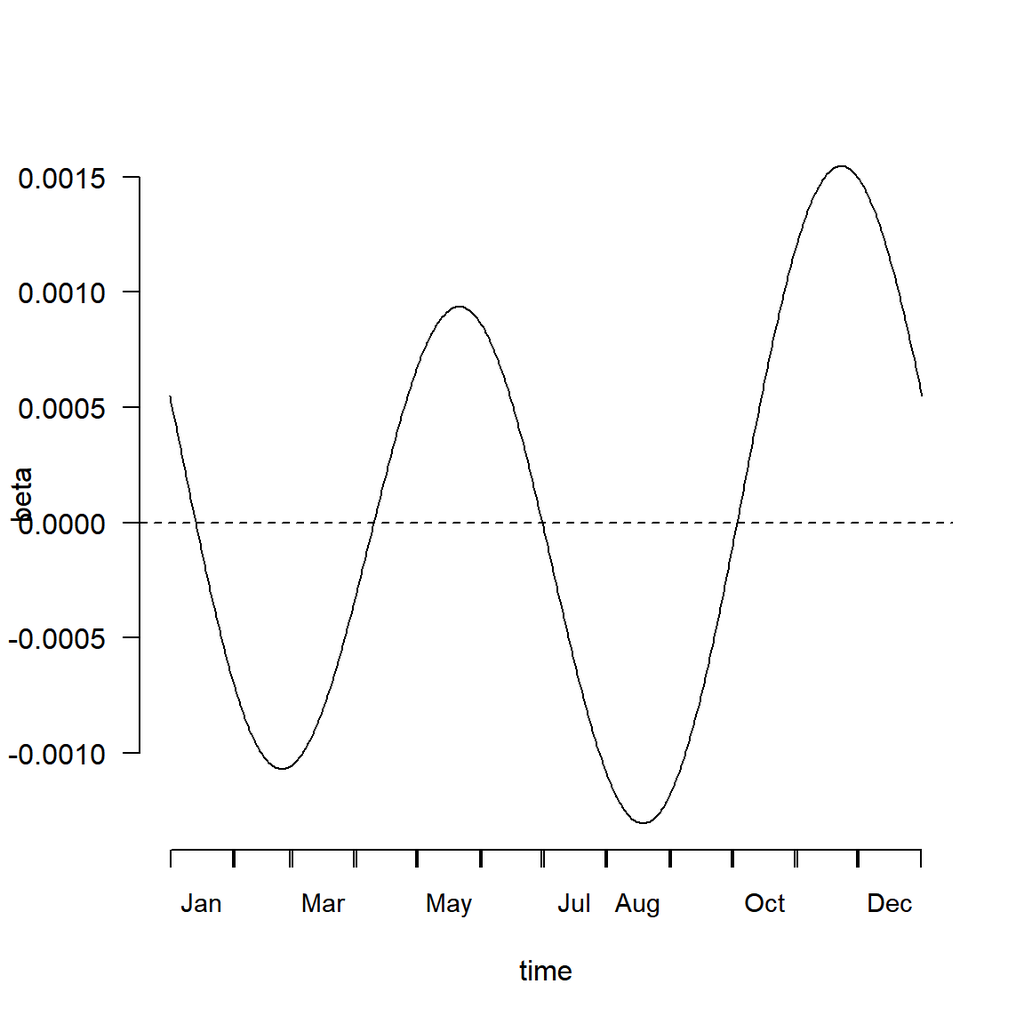

```
## [1] "done"
```

```r
annualprec <- log10(apply(CanadianWeather$dailyAv[,,"Precipitation.mm"],2,sum)) # annual precipitation
smallbasis <- create.fourier.basis(c(0, 365), 5,axes=list('axesIntervals'))
tempfd <- smooth.basis(day.5,CanadianWeather$dailyAv[,,"Temperature.C"], smallbasis)$fd
#### do function regression ####
precip.Temp.f <- fRegress(annualprec ~ tempfd)
#### estimated coefficient function ####
plot(precip.Temp.f$betaestlist$tempfd$fd,ylab="beta")
```

- 2월, 9월 경에 춥거나
- 5월, 11월 경에 온도가 높으면

연간 강수량이 많아지는 경향이 있다.

Prediction

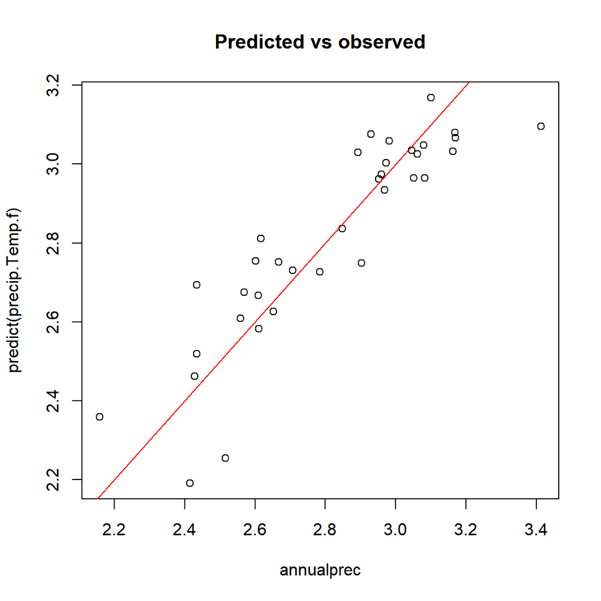

```r
plot(annualprec,predict(precip.Temp.f),main="Predicted vs observed")
abline(a=0,b=1,col=2)
```

#### Functional response model

$$y_i(t) = \beta_0(t) + \sum_{j=1}^p \beta_j(t)x_{ij} + \epsilon_i(t)$$

각 fixed $t$에서 linear model을 적합할 수 있다. 하지만, 적당한 smoothness penalty를 고려한다면,

Minimize

$$\sum_{i=1}^n \int ( y_i(t) - \hat y_i(t) )^2 dt + \sum_{j=1}^p \lambda_j \int (\beta_j''(t))^2 dt$$

#### Example : Weather data

$$temperature(t) \sim region$$

```r
daybasis65 <- create.fourier.basis(rangeval=c(0, 365), nbasis=65,
axes=list('axesIntervals'))
Temp.fd <- with(CanadianWeather, smooth.basisPar(day.5,
dailyAv[,,'Temperature.C'], daybasis65)$fd)
TempRgn.f <- fRegress(Temp.fd ~ region, CanadianWeather)
par(mfrow=c(1,4))
plot(TempRgn.f$betaestlist$const$fd,ylim=c(-30,30),main="Arctic")    # beta_0
```

```
## [1] "done"
```

```r
plot(TempRgn.f$betaestlist$region.Atlantic$fd,ylim=c(-30,30),main="Atlantic-Arctic")   # beta_1
```

```
## [1] "done"
```

```r
plot(TempRgn.f$betaestlist$region.Continental$fd,ylim=c(-30,30),main="Continental-Arctic")  # beta_2
```

```
## [1] "done"
```

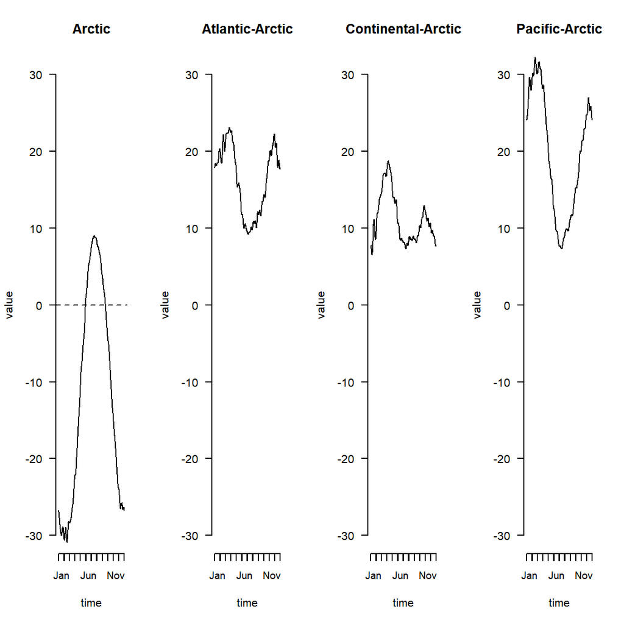

```
## [1] "done"
```

```r
plot(TempRgn.f$betaestlist$region.Pacific$fd,ylim=c(-30,30),main="Pacific-Arctic")  # beta_3
```

#### Functional response model : Concurrent Linear Model

$$y_i(t) = \beta_0(t) + \sum_{j=1}^p \beta_j(t)x_{ij}(t) + \epsilon_i(t)$$

#### Example : gait cycle

Gait cycle for hip and knee angle while walking

$$knee(t) \sim hip(t)$$

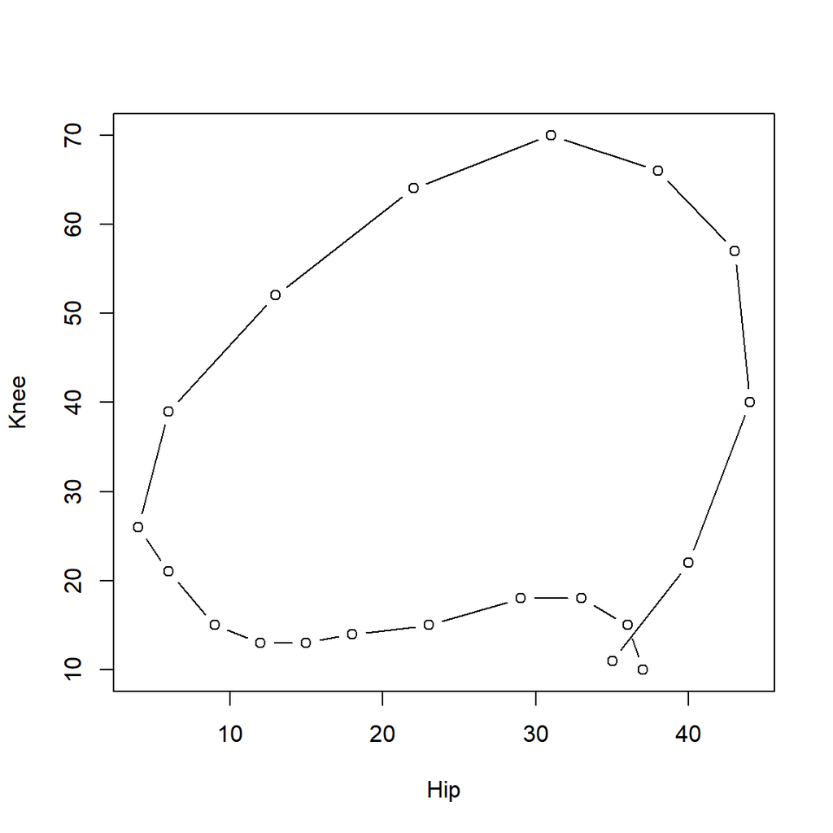

```r
plot(gait[,1, 1], gait[, 1, 2], type="b",xlab="Hip",ylab="Knee")
```

Smoothed data

```r
(gaittime <- as.numeric(dimnames(gait)[[1]])*20)
```

```
##  [1]  0.5  1.5  2.5  3.5  4.5  5.5  6.5  7.5  8.5  9.5 10.5 11.5 12.5 13.5
## [15] 14.5 15.5 16.5 17.5 18.5 19.5
```

```r
gaitrange <- c(0,20)
gaitbasis <- create.fourier.basis(gaitrange, nbasis=21)
#### Smoothing by using a user-specified penalty ####
gaitfd <- smooth.basisPar(gaittime, gait,gaitbasis, lambda=1e-2)$fd
hipfd <- gaitfd[,1]
kneefd <- gaitfd[,2]
par(mfrow=c(2,1))
plot(hipfd)
```

```
## [1] "done"
```

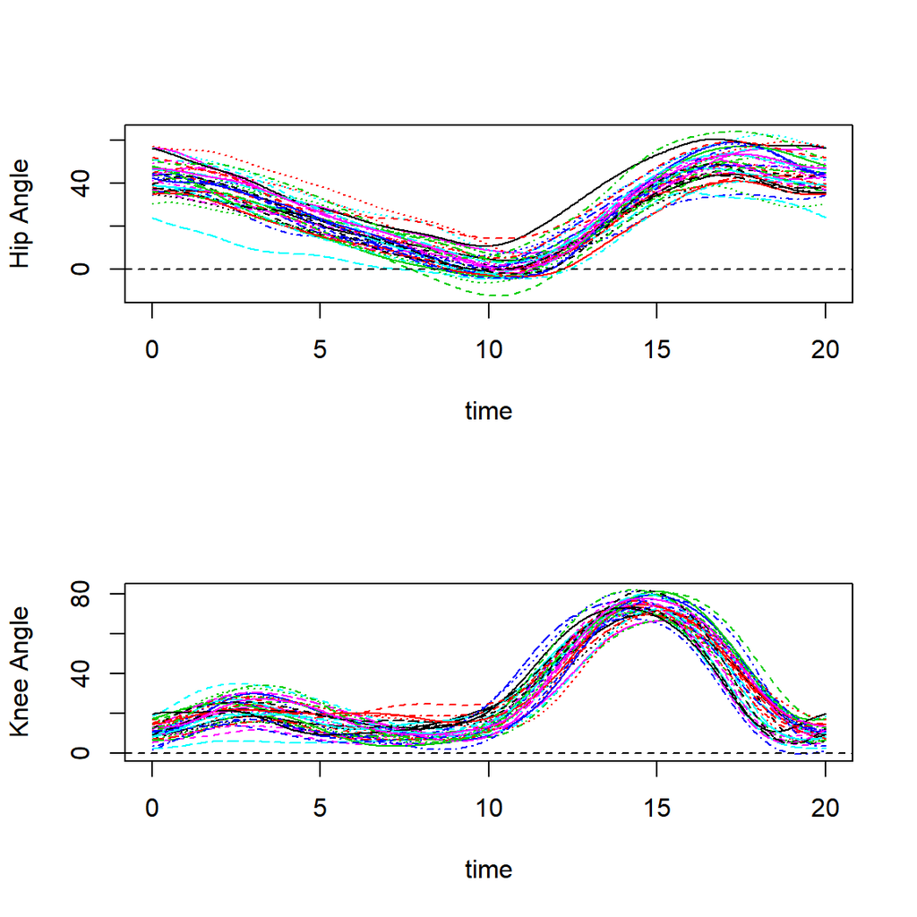

```
## [1] "done"
```

```r
plot(kneefd)
```

Estimated coefficient functions

```r
knee.hip.f <- fRegress(kneefd ~ hipfd)
par(mfrow=c(2,1))
plot(knee.hip.f$betaestlist$const$fd,ylab="")
```

```
## [1] "done"
```

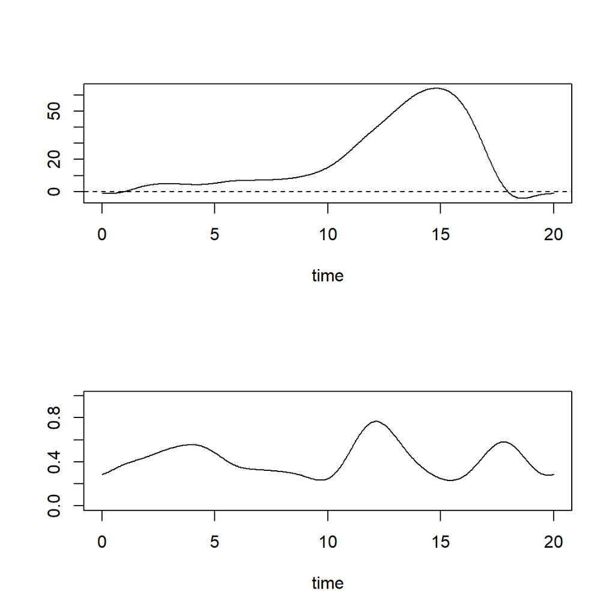

```
## [1] "done"
```

```r
plot(knee.hip.f$betaestlist$hipfd$fd,ylab="",ylim=c(0,1))
```

- $\hat\beta_0$는 자율적인 무릎의 움직임을 나타낸다.
- $\hat\beta_1$으로부터 hip이 더 많이 굽혀질 수록 무릎도 더 많이 굽혀지는 경향이 있음을 볼 수 있다.

#### Functional response : most general model

$$y_i(t) = \beta_0(t) + \int \beta(s,t)x_{i}(s)ds + \epsilon_i(t)$$

Thank you for your attention!!!